# A basic introduction to runoutSIM

Jason Goetz

2026-08-25

# Introduction

The `runoutSIM` package is developed for spatially simulating landslide runout across large areas using random walks. This document provides an introduction to applying `runoutSIM` for regional debris flow simulation using a subcatchment of the upper Maipo river basin, Chile as an example. In this vignette, we will:

- Load and visualize spatial data
- Simulate runout from single and multiple source cells
- Visualize simulation results as rasters and interactive maps

# Loading packages and reading spatial data

Spatial handling in the `runoutSIM` package is supported by the `sf` (fr vector data) and `terra` (for gridded/raster data) packages. In this example, we load/read a digital elevation model (DEM) with 12.5 m spatial resolution, polygons showing where debris flows have occurred, and corresponding source points mapped for each polygon. We also create a hillshade model to help with visualization of the results.

**Tip:** Currently, this package is designed to work with data in a UTM coordinate reference system (CRS). You will need to project your own data to a local UTM CRS for it to work.

```r
# load packages
library(runoutSIM)
library(terra)
library(sf)
# Load digital elevation model (DEM)
dem <- rast("Data/elev_fillsinks_WangLiu.tif")

# Compute hillshade for visualization
slope <- terrain(dem, "slope", unit="radians")
aspect <- terrain(dem, "aspect", unit="radians")
hill <- shade(slope, aspect, 40, 270)

# Load debris flow runout source points and polygons
source_points <- st_read("Data/debris_flow_source_points.shp")
runout_polygons <- st_read("Data/debris_flow_runout_polygons.shp")
# Load basin boundary
bnd_catchment <- st_read("Data/basin_rio_olivares.shp")
```

# Creating interactive maps

Using the `leafmap()` function, we can quickly create an interactive leaflet map for viewing the data. We use the `%>%` operator to pipe together multiple `leafmap()` calls to create a combined leaflet map with multiple layers.

**Tip:** `leafmap()` has the option to show raster values when you hover your mouse over the map. This option is turned on by default, but can result in a considerable increase in the file size of the leaflet widget (e.g. when exported for sharing). It is recommended to have `add_image_query = FALSE` when saving / exporting the leaflet map.

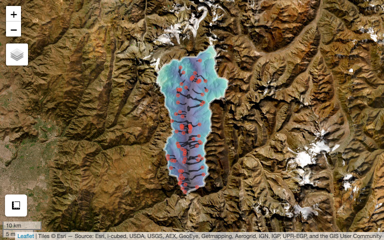

```r
map <- leafmap(bnd_catchment, color = '#f7f9f9', fill_color = '#FF000000', weight = 4) %>%
    leafmap(runout_polygons) %>%
    leafmap(source_points, color = '#e74c3c') %>%
    leafmap(hill, palette = grey(0:100/100), opacity = 1, add_legend = FALSE,
            add_image_query = FALSE) %>%
    leafmap(dem, palette = viridis::mako(10), opacity = 0.6, add_image_query = FALSE)
map
```

# Simulate runout from a single source cell

Runout paths are simulated from individual source cells, defined as x, y coordinates. For example, if we are simulating runout from a single source cell defined by a source point (vector data), we use `sf::st_coordinates()` to extract the x, y values.

```r
# Select a single debris flow and source point for the example
runout_polygon <- runout_polygons[31,]

# Get corresponding source point
source_point  <- st_filter(st_as_sf(source_points), st_as_sf(runout_polygon))

# Get coordinates of source point
source_crds <- st_coordinates(source_point)
print(source_crds)
```

```
#>             X       Y
#> [1,] 395698.1 6307421
```

Now that we have the coordinates, we can run the random walk runout simulations using `runoutSim()`. Where:

- `mu` and `md` are the sliding friction coefficient and mass-to-drag parameters of the two-parameter friction model controlling runout distance
- `slp_thresh`, `exp_div`, and `per_fct` are parameters controlling the dispersion of the random walks
- `walks` is the number of random walk iterations

```r
sim_paths = runoutSim(dem = dem,
                      xy = source_crds,
                      mu = 0.08,
                      md = 140,
                      slp_thresh = 35,
                      exp_div = 2.5,
                      per_fct = 1.95,
                      walks = 1000)

# plot structure of sim_paths
str(sim_paths)
```

```
#> List of 4
#>  $ start_cell    : num 2803625
#>  $ cell_trav_freq: 'table' int [1:2048(1d)] 5 2 2 14 11 10 3 50 56 40 ...
#>   ..- attr(*, "dimnames")=List of 1
#>   .. ..$ all_indices: chr [1:2048] "2774166" "2774167" "2775633" "2775634" ...
#>  $ cell_max_vel  : num [1:2048] 15.5 16.4 11.9 14.2 16.2 ...
#>  $ prob_connect  : NULL
```

`runoutSim()` returns a list containing:

- The cell number of the DEM indicating the location of the source cell
- Traverse frequencies for each grid cell, which shows the most likely flow paths
- Maximum velocities (m/s) for each grid cell

These values are stored as cell numbers. `prob_connect` is a value that can be calculated separately that provides the probability debris from the source cell can reach another feature of interest.

## Converting results to a raster

To visualize the results, we convert the output from `runoutSim()` to a raster.

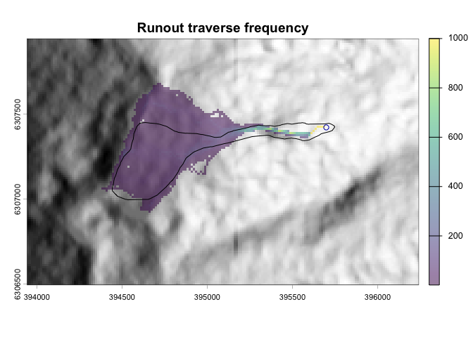

```r
## Convert paths to raster with cell transition frequencies
paths_raster <- walksToRaster(sim_paths, dem, method = "freq")

# Plot results
paths_raster <- crop(paths_raster, ext(runout_polygon)+500)
plot(crop(hill, ext(runout_polygon)+500), col=grey(0:100/100), legend=FALSE,
     mar=c(2,2,1,4), main = "Runout traverse frequency")
plot(paths_raster, legend = T, alpha = 0.5, add = TRUE)
plot(st_geometry(runout_polygon), add = TRUE)
plot(source_point, add = TRUE)
```

In `walksToRaster()`, we use `method = "freq"` to return traverse frequencies. We can also return traverse (ECDF) probabilities by using `method = "cdf_prob"`.

We use `velocityToRaster()` to create a raster of the velocity values of the debris flow (in m/s).

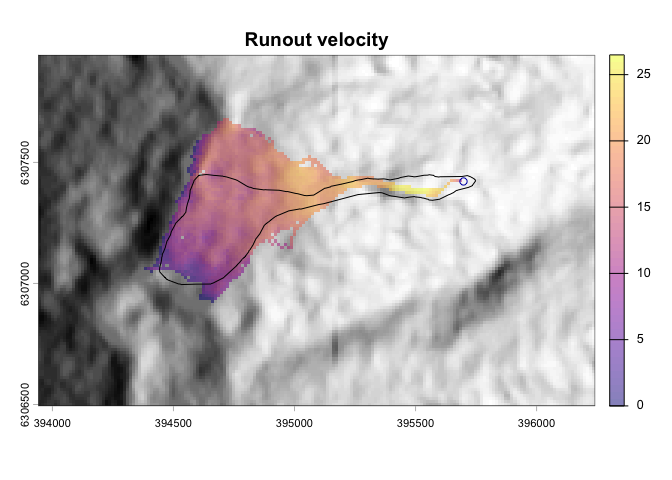

```r
## Convert paths to raster with max. velocities
vel_raster <- velocityToRaster(sim_paths, dem)

# Plot results
vel_raster <- crop(vel_raster, ext(runout_polygon)+500)
plot(crop(hill, ext(runout_polygon)+500), col=grey(0:100/100), legend=FALSE,
     mar=c(2,2,1,4), main = "Runout velocity")
plot(vel_raster, col = map.pal('plasma'), legend = TRUE, alpha = 0.5, add = TRUE)
plot(st_geometry(runout_polygon), add = TRUE)
plot(source_point, add = TRUE)
```

## Computing connectivity probability

The `runoutSim()` function also allows us to calculate the propotion of simulated debris paths that intersect a feature from a given source cell (i.e. connectivity probability).

In this example, we will determine the connectivity probability of a simulated debris flow to a river channel. Using `makeConnFeature()` function, we will create a matrix indicating with a value of 1 which cells contain the river channel.

```r
# Load river channel polygon (vector)
river_channel <- st_read("Data/river_channel.shp")
# Create a connectivity feature for runoutSim that matches the input DEM
feature_mask <- makeConnFeature(river_channel, dem)
```

Now that we have a connectivity feature, we can re-run `runoutSim()` with some additional parameter options: `source_connect = TRUE` allowing us to calculate a connectivity probability and `connect_feature = feature_mask`.

```r
sim_paths = runoutSim(dem = dem,
                      xy = source_crds,
                      mu = 0.08,
                      md = 140,
                      slp_thresh = 35,
                      exp_div = 2.5,
                      per_fct = 1.95,
                      walks = 1000,
                      source_connect = TRUE,
                      connect_feature = feature_mask)

# Plot structure of sim_paths
str(sim_paths)
```

```
#> List of 4
#>  $ start_cell    : num 2803625
#>  $ cell_trav_freq: 'table' int [1:1990(1d)] 6 3 4 19 9 8 6 49 51 37 ...
#>   ..- attr(*, "dimnames")=List of 1
#>   .. ..$ all_indices: chr [1:1990] "2774166" "2774167" "2775633" "2775634" ...
#>  $ cell_max_vel  : num [1:1990] 15.2 16.3 12 14.2 16.2 ...
#>  $ prob_connect  : num 0.826
```

```r
# Get connectivity probability
sim_paths$prob_connect
```

```
#> [1] 0.826
```

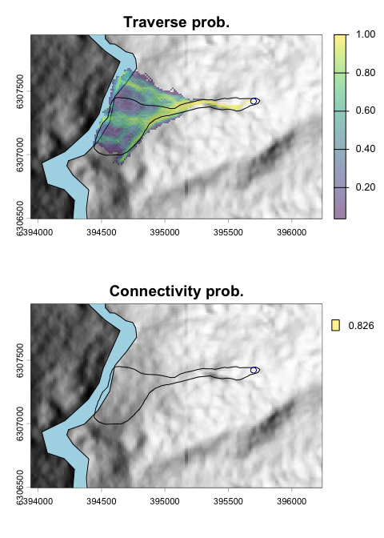

```r
tp_raster <- walksToRaster(sim_paths, dem, method = "cdf_prob")
conn_raster <- connToRaster(sim_paths, dem)

# Crop results
tp_crop <- crop(tp_raster, ext(runout_polygon)+ 500)
conn_crop <- crop(conn_raster, ext(runout_polygon)+ 500)

# Plot results
par(mfrow = c(2,1))
plot(crop(hill, ext(runout_polygon)+500), col=grey(0:100/100), legend=FALSE,
     mar=c(2,2,1,4), main = "Traverse prob.")
plot(st_geometry(river_channel), col = "lightblue", add = TRUE)
plot(tp_crop, legend = TRUE, alpha = 0.5, add = TRUE)
plot(st_geometry(runout_polygon), add = TRUE)
plot(source_point, add = TRUE)


plot(crop(hill, ext(runout_polygon)+500), col=grey(0:100/100), legend=FALSE,
     mar=c(2,2,1,4), main = "Connectivity prob.")
plot(st_geometry(river_channel), col = "lightblue", add = TRUE)
plot(conn_crop, legend = TRUE, alpha = 0.5, add = TRUE)
plot(st_geometry(runout_polygon), add = TRUE)
plot(source_point, add = TRUE)
```

# Simulate runout from multiple-sources

To simulate runout from multiple source cell locations, we run `runoutSim()` iteratively, changing the xy coordinates during each iteration.

To create a list of xy coordinates from source points (vector), we use the `makeSourceList()` function.

```r
# Get coordinates of source points to create a source list object
source_l <- makeSourceList(source_points)

# Perform random walk simulation for each source point
sim_runs <- list()

for(i in 1:length(source_l)){

  sim_runs[[i]] <- runoutSim(dem = dem, xy = source_l[[i]],
                              mu = 0.08,
                              md = 40,
                              slp_thresh = 40,
                              exp_div = 3,
                              per_fct = 1.9,
                              walks = 1000)
}
```

We can now convert this list of multiple random walks from different source cells to raster data using `walksToRaster()` and `velocityToRaster()`.

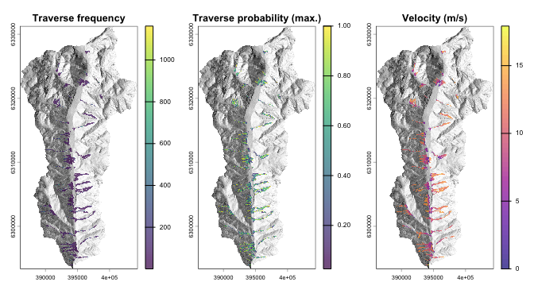

```r
# Coerce results to a raster
trav_freq <- walksToRaster(sim_runs, method = "freq", dem)
vel_ms <- velocityToRaster(sim_runs, dem, method = "max")
trav_prob <- walksToRaster(sim_runs, method = "max_cdf_prob", dem)


# Plot random walks from mulitple source cells
par(mfrow = c(1,3))
plot(hill, col=grey(0:100/100), legend=FALSE, mar=c(2,2,1,4),
     main = "Traverse frequency")
plot(trav_freq, add = TRUE, alpha = 0.7)

plot(hill, col=grey(0:100/100), legend=FALSE, mar=c(2,2,1,4),
     main = "Traverse probability (max.)")
plot(trav_prob, add = TRUE, alpha = 0.7)

plot(hill, col=grey(0:100/100), legend=FALSE, mar=c(2,2,1,4),
     main = "Velocity (m/s)")
plot(vel_ms, col = map.pal("plasma"), add = TRUE, alpha = 0.7)
```

We can also view the results through an interactive leaflet map.

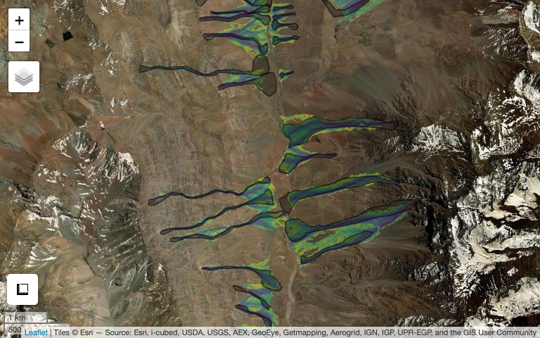

```r
# Create interactive leaflet map
sim_map <-
  # Debris flow observations
  leafmap(runout_polygons, opacity = 0.3, label = "Runout polygons") %>%
  leafmap(source_points, color = '#e74c3c', label = "Source points") %>%
  # Terrain data
  leafmap(hill, palette = grey(0:100/100), opacity = 1, add_legend = FALSE,
            add_image_query = FALSE, label = "Hillshade") %>%
  leafmap(dem, palette = viridis::mako(10), opacity = 0.6,
          add_image_query = FALSE, label = "DEM") %>%
  # Modelling results
  leafmap(trav_prob,  palette = viridis::viridis(10, direction = -1),
          label = "Traverse prob", add_image_query = FALSE) %>%
  leafmap(vel_ms,  palette = viridis::plasma(10, direction = -1),
          label = "Velocity", add_image_query = FALSE)

# Start with mapped zoomed in
sim_map <- leaflet::setView(sim_map, lng = -70.13694, lat = -33.3703, zoom = 13)


# Hide layers
sim_map <- leaflet::hideGroup(sim_map, c("Velocity", "Source points", "DEM", "Hillshade"))

sim_map
```